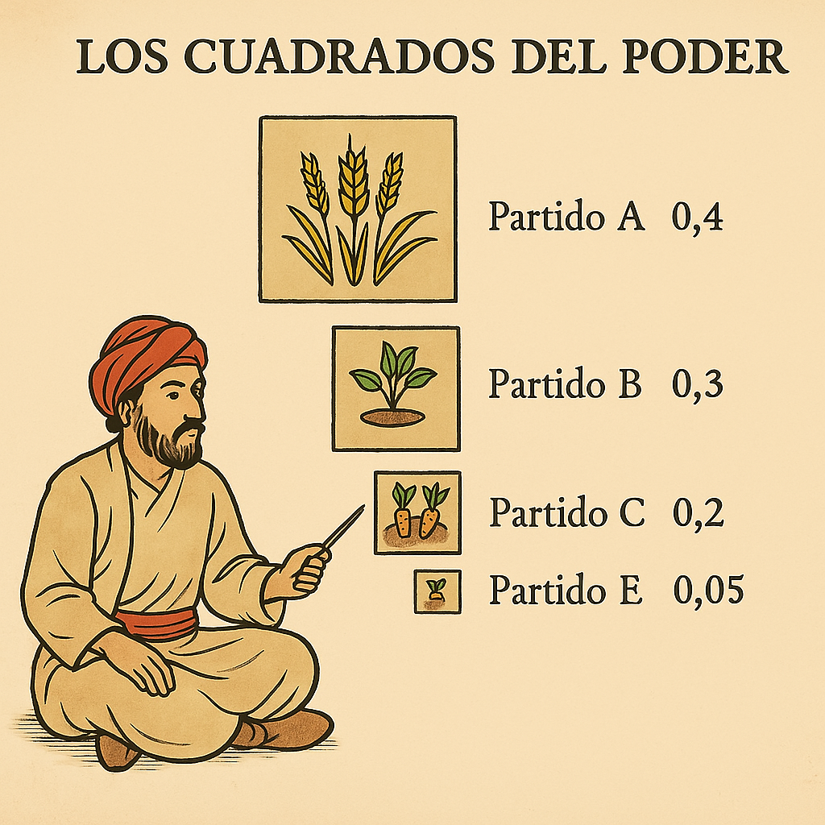

# El sabio de Samarcanda y los cuadrados del poder

Mientras cruzábamos los bazares perfumados de **Samarcanda**, mi maestro Beremiz Samir —el Hombre que Calculaba— fue abordado por un joven visir de voz suave y túnica bordada en hilos de oro.

—Oh sabio del cálculo —dijo—, en nuestra asamblea hay cinco partidos. Pero aunque todos figuran en los documentos, sabemos que no todos cuentan igual. Queremos saber cuántos partidos **realmente existen**, es decir, cuántos *mandan de verdad*.

—Ah —respondió Beremiz—, buscas el **número efectivo de partidos**, no el aparente.

Y sin más, tomó su bastón y trazó un gran rectángulo en la arena. Lo dividió en cinco zonas proporcionales al poder de los partidos:

- Partido A: 40% (0.4, cuando lo expresamos como una proporción)
- Partido B: 30% (0.3)
- Partido C: 20% (0.2)
- Partido D: 5% (0.05)
- Partido E: 5% (0.05)

—Pero maestro —preguntó el visir—, ¿por qué no contar simplemente los partidos? ¿O usar las proporciones sin más?

Beremiz le sonrió con paciencia.

—Escucha, joven aprendiz. Déjame hablarte de dos agricultores del valle de Ferghana.

Dibujó dos campos imaginarios sobre la arena.

—Uno de ellos tenía un cultivo cuadrado de **9 kilómetros de lado**, es decir, un área de 81 km². El otro, un terreno de **8 kilómetros de lado**: su campo sumaba 64 km². Una diferencia de **una sola unidad en la línea**, pero de **17 en el área cultivada**.

Se inclinó y, con un gesto lento, añadió:

—Con 64 kilómetros apenas se asegura el trigo para los panes. Pero con 81, además del pan, queda espacio para dátiles y especias, manjares de otro orden. ¿Ves? Una pequeña ventaja lineal se convierte en un mundo de nuevas posibilidades.

Alzó la mirada hacia el visir.

—Así ocurre con el poder político. No crece como una línea, sino como un campo fértil. Un poco más de proporción puede significar no solo más fuerza, sino otro **tipo de fuerza**: la que decide qué se planta, qué se come, y hasta quién tiene derecho a sentarse a la mesa.

Y dibujó cinco cuadrados, con lados equivalentes a las proporciones de cada partido. El de 40% era amplio y visible. Los de 5%, apenas puntos en la arena.

—Veamos —dijo—. Calculamos así:

$$N_e = \frac{1}{(0.4)^2 + (0.3)^2 + (0.2)^2 + (0.05)^2 + (0.05)^2}$$

$$N_e= \frac{1}{0.16 + 0.09 + 0.04 + 0.0025 + 0.0025} = \frac{1}{0.295} \approx 3.39$$

—Aunque hay cinco partidos, su efecto real equivale a **poco más de tres partidos iguales**. Los demás apenas siembran, y lo que cosechan no cambia el banquete.

El visir lo miraba embelesado.

—¿Y si todos tuvieran el mismo tamaño?

Beremiz trazó cinco cuadrados idénticos de 20%.

$$N_e = \frac{1}{5 \cdot (0.2)^2} = \frac{1}{0.2} = 5$$

—Eso sería **pluralismo perfecto**. Y si un solo partido tuviera todo el poder…

$$N_e = \frac{1}{1^2} = 1$$

—Entonces no hay pluralidad, solo **hegemonía disfrazada de variedad**.

El visir sonrió con súbita claridad.

—¡Ahora entiendo! El poder se mide como el terreno cultivado: no por el borde, sino por la cosecha que deja. Y los pequeños, aunque estén presentes, apenas logran pan; mientras que los grandes siembran no solo trigo, sino también festines enteros.

Y así, mientras las palomas cruzaban el cielo de Samarcanda, mi maestro transformó la política en geometría y la geometría en sabiduría.

## Simulador del Número Efectivo de Partidos

*Ahora tú puedes ser como Beremiz y calcular el poder real de los partidos. Ajusta los porcentajes y observa cómo cambia el número efectivo.*

### Simulador Interactivo

Partido A: %

Partido F: %

Partido B: %

Partido G: %

Partido C: %

Partido H: %

Partido D: %

Partido I: %

Partido E: %

Partido J: %

NEP = 3.39

NEP = 1 / (0.40² + 0.30² + 0.20² + 0.05² + 0.05²) = 1 / 0.295 = 3.39

**Interpretación:** Sistema moderadamente fragmentado. Aunque hay 5 partidos, el poder efectivo se concentra en aproximadamente 3.4 partidos. Los partidos pequeños tienen influencia muy limitada.

## Interpretación Pedagógica

El simulador te permite experimentar con diferentes distribuciones de poder y observar cómo:

1. **Pequeños cambios** en los partidos grandes tienen **gran impacto** en el NEP
2. **Partidos muy pequeños** apenas afectan el resultado (como los campos diminutos de Beremiz)
3. La **distribución perfectamente igual** siempre da NEP = número de partidos
4. Un **sistema hegemónico** se acerca a NEP = 1, sin importar cuántos partidos menores existan

*Como diría Beremiz: “La sabiduría está en ver que los números revelan la verdadera naturaleza del poder.”*